# Climate Water Loss Experiment - Weather Over Time

Savannah Weaver

2021

# Packages

```r
if (!require("tidyverse")) install.packages("tidyverse")
library("tidyverse") # workflow and plots
if (!require("weathermetrics")) install.packages("weathermetrics")
library("weathermetrics") # F to C conversion
if (!require("RColorBrewer")) install.packages("RColorBrewer")
library("RColorBrewer") # color
if (!require("ggpubr")) install.packages("ggpubr")
library("ggpubr") # for multi-ggplot figs
if (!require("rmdformats")) install.packages("rmdformats")
library("rmdformats") # clean html R markdown format
```

# Background

Our analyses of baseline variation in CEWL and plasma osmolality yielded VERY different models for this current project/dataset compared to our last iteration of data collection (DOI:10.1655/Herpetologica-D-21-00030.1). In this Rmd, I investigate the weather trends across both studies to assess whether variation, or lack of, in weather may have led to the very different results we got.

I also want to know how close our treatment climates were to what the lizards experience in the wild, and I quantify that in this file.

The weather at capture that is used in the models of baseline variation are read-in in the “wrangling_general” file and analysed in the “analysis_capture” file.

# Load Data

first, get the sunrise and sunset times March - September: (source: https://gml.noaa.gov/grad/solcalc/table.php?lat=35.304442&lon=-120.65925&year=2021)

sunrise times:

```r
sunrises <- read.csv("./data/sunrise_SLO_2021.csv")
rise_March <- sunrises %>%
  dplyr::select(Day, time = Mar) %>%
  mutate(date = paste("2021", "03", Day, sep = "-"),
         sunrise = as.POSIXct(paste(date, time, sep = " ")))
rise_April <- sunrises %>%
  dplyr::select(Day, time = Apr) %>%
  dplyr::filter(time != "") %>%
  mutate(date = paste("2021", "04", Day, sep = "-"),
         sunrise = as.POSIXct(paste(date, time, sep = " ")))
rise_May <- sunrises %>%
  dplyr::select(Day, time = May) %>%
  dplyr::filter(time != "") %>%
  mutate(date = paste("2021", "05", Day, sep = "-"),
         sunrise = as.POSIXct(paste(date, time, sep = " ")))
rise_June <- sunrises %>%
  dplyr::select(Day, time = Jun) %>%
  dplyr::filter(time != "") %>%
  mutate(date = paste("2021", "06", Day, sep = "-"),
         sunrise = as.POSIXct(paste(date, time, sep = " ")))
rise_July <- sunrises %>%
  dplyr::select(Day, time = Jul) %>%
  dplyr::filter(time != "") %>%
  mutate(date = paste("2021", "07", Day, sep = "-"),
         sunrise = as.POSIXct(paste(date, time, sep = " ")))
rise_August <- sunrises %>%
  dplyr::select(Day, time = Aug) %>%
  dplyr::filter(time != "") %>%
  mutate(date = paste("2021", "08", Day, sep = "-"),
         sunrise = as.POSIXct(paste(date, time, sep = " ")))
rise_September <- sunrises %>%
  dplyr::select(Day, time = Sep) %>%
  dplyr::filter(time != "") %>%
  mutate(date = paste("2021", "09", Day, sep = "-"),
         sunrise = as.POSIXct(paste(date, time, sep = " ")))

sunrises_formatted <- rise_March %>%
  rbind(rise_April) %>%
  rbind(rise_May) %>%
  rbind(rise_June) %>%
  rbind(rise_July) %>%
  rbind(rise_August) %>%
  rbind(rise_September) %>%
  dplyr::select(date, sunrise) %>%
  mutate(date = as.Date(date))
```

sunset times:

```r
sunsets <- read.csv("./data/sunset_SLO_2021.csv")
set_March <- sunsets %>%
  dplyr::select(Day, time = Mar) %>%
  mutate(date = paste("2021", "03", Day, sep = "-"),
         sunset = as.POSIXct(paste(date, time, sep = " ")))
set_April <- sunsets %>%
  dplyr::select(Day, time = Apr) %>%
  dplyr::filter(time != "") %>%
  mutate(date = paste("2021", "04", Day, sep = "-"),
         sunset = as.POSIXct(paste(date, time, sep = " ")))
set_May <- sunsets %>%
  dplyr::select(Day, time = May) %>%
  dplyr::filter(time != "") %>%
  mutate(date = paste("2021", "05", Day, sep = "-"),
         sunset = as.POSIXct(paste(date, time, sep = " ")))
set_June <- sunsets %>%
  dplyr::select(Day, time = Jun) %>%
  dplyr::filter(time != "") %>%
  mutate(date = paste("2021", "06", Day, sep = "-"),
         sunset = as.POSIXct(paste(date, time, sep = " ")))
set_July <- sunsets %>%
  dplyr::select(Day, time = Jul) %>%
  dplyr::filter(time != "") %>%
  mutate(date = paste("2021", "07", Day, sep = "-"),
         sunset = as.POSIXct(paste(date, time, sep = " ")))
set_August <- sunsets %>%
  dplyr::select(Day, time = Aug) %>%
  dplyr::filter(time != "") %>%
  mutate(date = paste("2021", "08", Day, sep = "-"),
         sunset = as.POSIXct(paste(date, time, sep = " ")))
set_September <- sunsets %>%
  dplyr::select(Day, time = Sep) %>%
  dplyr::filter(time != "") %>%
  mutate(date = paste("2021", "09", Day, sep = "-"),
         sunset = as.POSIXct(paste(date, time, sep = " ")))

sunsets_formatted <- set_March %>%
  rbind(set_April) %>%
  rbind(set_May) %>%
  rbind(set_June) %>%
  rbind(set_July) %>%
  rbind(set_August) %>%
  rbind(set_September) %>%
  dplyr::select(date, sunset) %>%
  mutate(date = as.Date(date))
```

load in weather data from ITRC:

```r
# ALL DATA
weather_dat_XL <- read.csv("./data/weather_long_term.csv", sep = ';') %>%
  mutate(temperature_F = as.numeric(temperature_F),
         wind_speed_mph = as.numeric(wind_speed_mph),
         RH_percent = as.numeric(RH_percent),
         solar_radiation_W_m2 = as.numeric(solar_radiation_W_m2),
         date_time = as.POSIXct(paste(date, time),
                                format = "%m/%d/%y %I:%M %p"),
         date = as.Date(date, format = "%m/%d/%y"),
         temp_C = fahrenheit.to.celsius(temperature_F, round = 2),
         temp_K = temp_C + 273.15,
         e_s_kPa = 0.611*exp((2500000/461.5)*
                                  ((1/273)-(1/temp_K))),
         e_a_kPa = e_s_kPa * (RH_percent/100),
         VPD_kPa = e_s_kPa - e_a_kPa,
         e_s_kPa_CN98 = 0.611 * exp((17.502*temp_C)/(temp_C + 240.97)),
         # VPD, Campbell & Normal 1998
         VPD_kPa_CN98 = e_s_kPa_CN98*(1 - (RH_percent/100))
         ) %>%
  dplyr::filter(complete.cases(temp_C, VPD_kPa_CN98))
# data for across both studies
weather_dat <- weather_dat_XL %>%
  dplyr::filter(date_time >= "2021-04-01 00:00:00" &
                  date_time <= "2021-09-01 00:00:00")

# data for the entire, conservative active season of these lizards
weather_dat_active_szn <- weather_dat_XL %>%
  dplyr::filter(date_time >= "2021-03-01 00:00:00" &
                  date_time <= "2021-10-01 00:00:00") %>%
  # add sunrise and sunset times
  left_join(sunrises_formatted, by = 'date') %>%
  left_join(sunsets_formatted, by = 'date') %>%
  group_by(date) %>%
  mutate(daytime = case_when(date_time >= sunrise & date_time <= sunset ~ "day",
                             date_time < sunrise ~ "night",
                             date_time > sunset ~ "night"),
         daytime = as.factor(daytime)) %>%
  dplyr::filter(daytime == "day")
summary(weather_dat_active_szn)
```

```
##       date                time           temperature_F    wind_speed_mph
##  Min.   :2021-03-01   Length:11473       Min.   : 35.60   Min.   : 0.100
##  1st Qu.:2021-04-27   Class :character   1st Qu.: 57.20   1st Qu.: 2.000
##  Median :2021-06-17   Mode  :character   Median : 64.00   Median : 3.700
##  Mean   :2021-06-16                      Mean   : 64.55   Mean   : 3.374
##  3rd Qu.:2021-08-06                      3rd Qu.: 71.80   3rd Qu.: 4.800
##  Max.   :2021-09-30                      Max.   :101.00   Max.   :14.300
##    RH_percent     solar_radiation_W_m2 precip_inches
##  Min.   : 13.70   Min.   :   0.0       Length:11473
##  1st Qu.: 61.40   1st Qu.: 131.8       Class :character
##  Median : 70.60   Median : 502.8       Mode  :character
##  Mean   : 72.47   Mean   : 498.9
##  3rd Qu.: 87.00   3rd Qu.: 842.1
##  Max.   :100.00   Max.   :1156.4
##    date_time                          temp_C          temp_K
##  Min.   :2021-03-01 06:45:00.00   Min.   : 2.00   Min.   :275.1
##  1st Qu.:2021-04-27 11:30:00.00   1st Qu.:14.00   1st Qu.:287.1
##  Median :2021-06-17 06:30:00.00   Median :17.78   Median :290.9
##  Mean   :2021-06-16 17:19:20.11   Mean   :18.08   Mean   :291.2
##  3rd Qu.:2021-08-06 08:00:00.00   3rd Qu.:22.11   3rd Qu.:295.3
##  Max.   :2021-09-30 18:45:00.00   Max.   :38.33   Max.   :311.5
##     e_s_kPa          e_a_kPa          VPD_kPa        e_s_kPa_CN98
##  Min.   :0.7135   Min.   :0.4162   Min.   :0.0000   Min.   :0.7057
##  1st Qu.:1.6244   1st Qu.:1.2374   1st Qu.:0.2163   1st Qu.:1.5974
##  Median :2.0756   Median :1.5543   Median :0.6060   Median :2.0340
##  Mean   :2.2283   Mean   :1.5068   Mean   :0.7215   Mean   :2.1773
##  3rd Qu.:2.7273   3rd Qu.:1.7893   3rd Qu.:1.0077   3rd Qu.:2.6598
##  Max.   :7.0903   Max.   :2.2082   Max.   :5.8841   Max.   :6.7480
##   VPD_kPa_CN98       sunrise
##  Min.   :0.0000   Min.   :2021-03-01 06:32:00.00
##  1st Qu.:0.2128   1st Qu.:2021-04-27 06:15:00.00
##  Median :0.5936   Median :2021-06-17 05:48:00.00
##  Mean   :0.7030   Mean   :2021-06-16 10:35:14.82
##  3rd Qu.:0.9828   3rd Qu.:2021-08-06 06:16:00.00
##  Max.   :5.6012   Max.   :2021-09-30 06:57:00.00
##      sunset                        daytime
##  Min.   :2021-03-01 17:58:00.00   day  :11473
##  1st Qu.:2021-04-27 19:46:00.00   night:    0
##  Median :2021-06-17 20:20:00.00
##  Mean   :2021-06-17 00:02:19.61
##  3rd Qu.:2021-08-06 20:01:00.00
##  Max.   :2021-09-30 18:47:00.00
```

get average daily values:

```r
weather_dat_daily <- weather_dat %>%
  group_by(date) %>%
  summarise(temp_C = mean(temp_C),
            VPD_kPa = mean(VPD_kPa_CN98),
            RH_percent = mean(RH_percent),
            wind_speed_mph = mean(wind_speed_mph),
            solar_radiation_W_m2 = mean(solar_radiation_W_m2)
            )
```

# Visualize Trends Over Time

The vertical lines added indicate the days we captured lizards for both studies conducted in 2021.

## Temperature

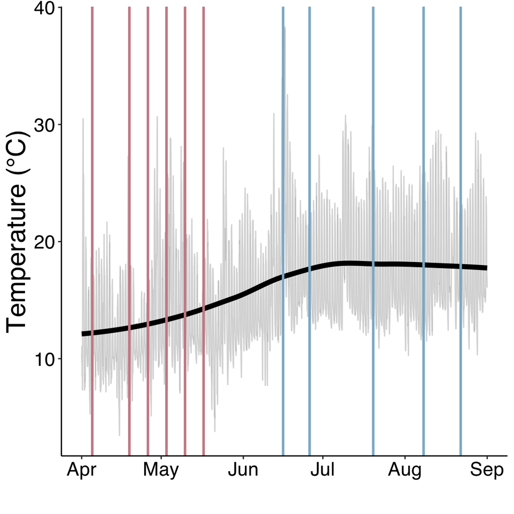

```r
ggplot(data = weather_dat,
       aes(x = date_time,
                y = temp_C)) +
  # all data
  geom_line(alpha = 0.6,
            color = "gray") +
  # trend over time
  stat_smooth(formula = y ~ x,
              method = "loess",
              color = "black",
              se = F,
              size = 2,
              alpha = 1 ) +
  # sampling dates for BOTH studies
  geom_vline(xintercept = as.POSIXct("2021-04-05 00:00:00"), size = 1,
             color = "lightpink3") +
  geom_vline(xintercept = as.POSIXct("2021-04-19 00:00:00"), size = 1,
             color = "lightpink3") +
  geom_vline(xintercept = as.POSIXct("2021-04-26 00:00:00"), size = 1,
             color = "lightpink3") +
  geom_vline(xintercept = as.POSIXct("2021-05-03 00:00:00"), size = 1,
             color = "lightpink3") +
  geom_vline(xintercept = as.POSIXct("2021-05-10 00:00:00"), size = 1,
             color = "lightpink3") +
  geom_vline(xintercept = as.POSIXct("2021-05-17 00:00:00"), size = 1,
             color = "lightpink3") +
  geom_vline(xintercept = as.POSIXct("2021-06-16 00:00:00"), size = 1,
             color = "lightskyblue3") +
  geom_vline(xintercept = as.POSIXct("2021-06-26 00:00:00"), size = 1,
             color = "lightskyblue3") +
  geom_vline(xintercept = as.POSIXct("2021-07-20 00:00:00"), size = 1,
             color = "lightskyblue3") +
  geom_vline(xintercept = as.POSIXct("2021-08-08 00:00:00"), size = 1,
             color = "lightskyblue3") +
  geom_vline(xintercept = as.POSIXct("2021-08-22 00:00:00"), size = 1,
             color = "lightskyblue3") +
  # rest is formatting
  theme_classic() +
  xlab("") +
  ylab("Temperature (°C)") +
  theme(text = element_text(color = "black",
                            family = "sans",
                            size = 22),
        axis.text = element_text(color = "black",
                                 family = "sans",
                                 size = 16),
        legend.text = element_text(color = "black",
                                 family = "sans",
                                 size = 14),
        legend.text.align = 0,
        legend.position = "right"
        ) -> temp_fig
temp_fig
```

## VPD

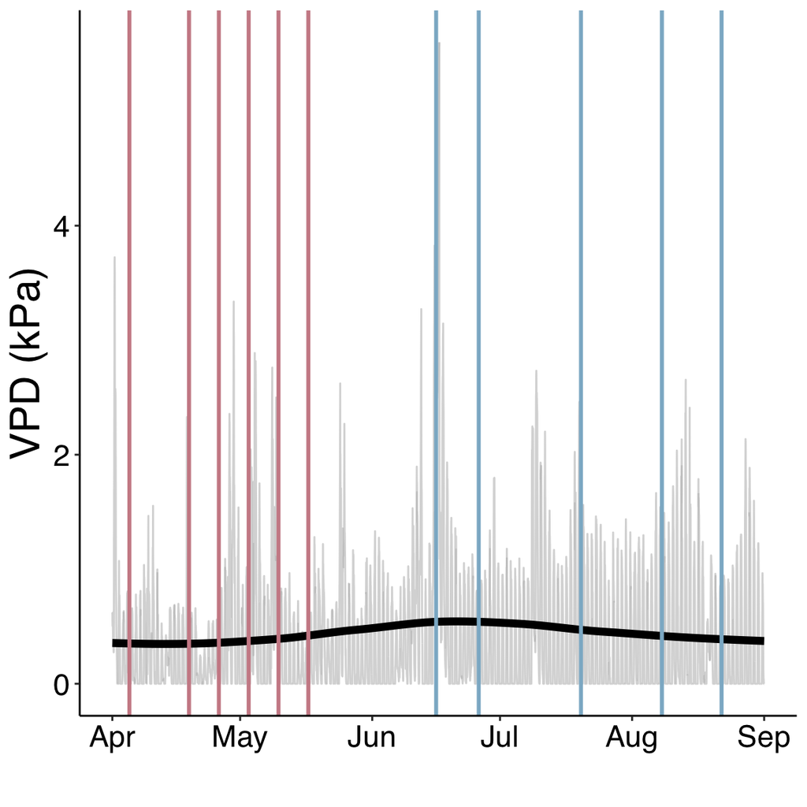

```r
ggplot(data = weather_dat,
       aes(x = date_time,
                y = VPD_kPa_CN98)) +
  # all data
  geom_line(alpha = 0.6,
            color = "gray") +
  # trend over time
  stat_smooth(formula = y ~ x,
              method = "loess",
              color = "black",
              se = F,
              size = 2,
              alpha = 1 ) +
  # sampling dates for BOTH studies
  geom_vline(xintercept = as.POSIXct("2021-04-05 00:00:00"), size = 1,
             color = "lightpink3") +
  geom_vline(xintercept = as.POSIXct("2021-04-19 00:00:00"), size = 1,
             color = "lightpink3") +
  geom_vline(xintercept = as.POSIXct("2021-04-26 00:00:00"), size = 1,
             color = "lightpink3") +
  geom_vline(xintercept = as.POSIXct("2021-05-03 00:00:00"), size = 1,
             color = "lightpink3") +
  geom_vline(xintercept = as.POSIXct("2021-05-10 00:00:00"), size = 1,
             color = "lightpink3") +
  geom_vline(xintercept = as.POSIXct("2021-05-17 00:00:00"), size = 1,
             color = "lightpink3") +
  geom_vline(xintercept = as.POSIXct("2021-06-16 00:00:00"), size = 1,
             color = "lightskyblue3") +
  geom_vline(xintercept = as.POSIXct("2021-06-26 00:00:00"), size = 1,
             color = "lightskyblue3") +
  geom_vline(xintercept = as.POSIXct("2021-07-20 00:00:00"), size = 1,
             color = "lightskyblue3") +
  geom_vline(xintercept = as.POSIXct("2021-08-08 00:00:00"), size = 1,
             color = "lightskyblue3") +
  geom_vline(xintercept = as.POSIXct("2021-08-22 00:00:00"), size = 1,
             color = "lightskyblue3") +
  # rest is formatting
  theme_classic() +
  xlab("") +
  ylab("VPD (kPa)") +
  theme(text = element_text(color = "black",
                            family = "sans",
                            size = 22),
        axis.text = element_text(color = "black",
                                 family = "sans",
                                 size = 16),
        legend.text = element_text(color = "black",
                                 family = "sans",
                                 size = 14),
        legend.text.align = 0,
        legend.position = "right"
        ) -> VPD_fig
VPD_fig
```

## Wind Speed

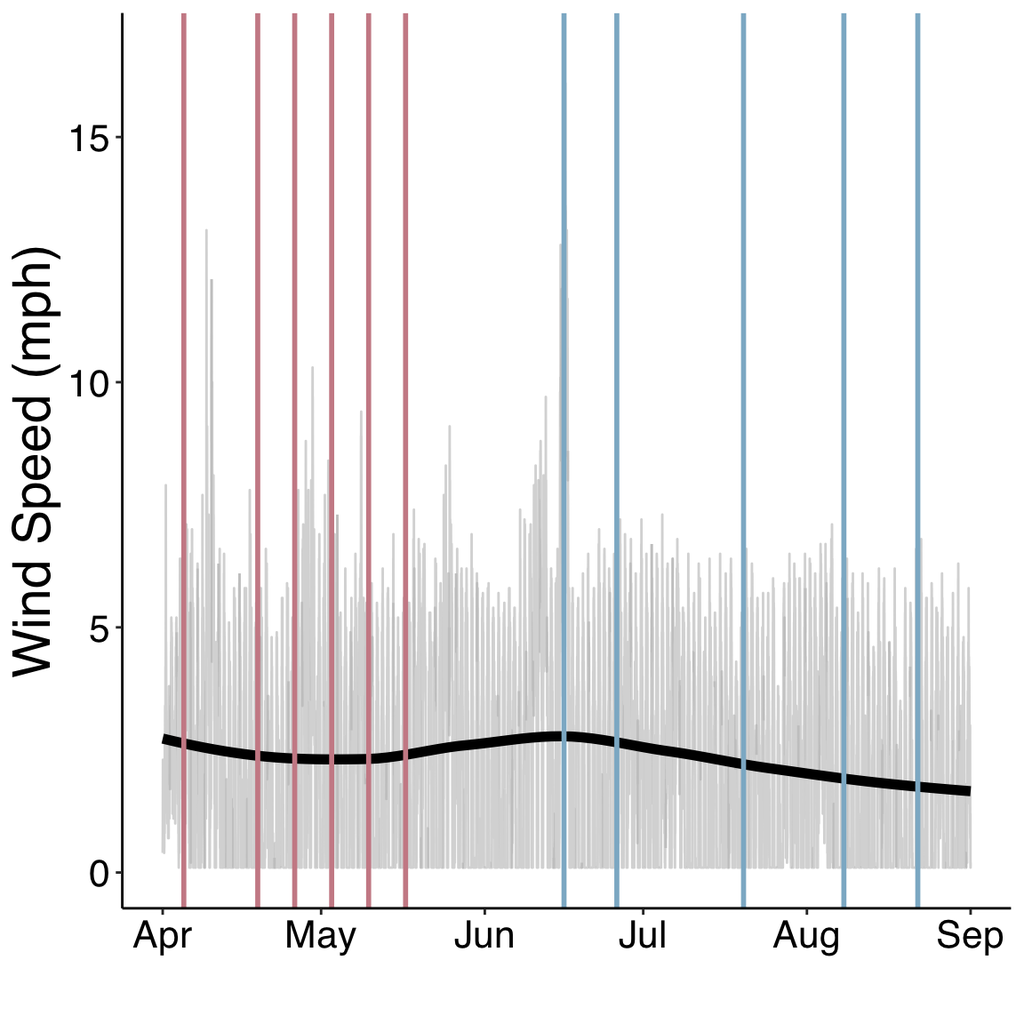

```r
ggplot(data = weather_dat,
       aes(x = date_time,
                y = wind_speed_mph)) +
  # all data
  geom_line(alpha = 0.6,
            color = "gray") +
  # trend over time
  stat_smooth(formula = y ~ x,
              method = "loess",
              color = "black",
              se = F,
              size = 2,
              alpha = 1 ) +
  # sampling dates for BOTH studies
  geom_vline(xintercept = as.POSIXct("2021-04-05 00:00:00"), size = 1,
             color = "lightpink3") +
  geom_vline(xintercept = as.POSIXct("2021-04-19 00:00:00"), size = 1,
             color = "lightpink3") +
  geom_vline(xintercept = as.POSIXct("2021-04-26 00:00:00"), size = 1,
             color = "lightpink3") +
  geom_vline(xintercept = as.POSIXct("2021-05-03 00:00:00"), size = 1,
             color = "lightpink3") +
  geom_vline(xintercept = as.POSIXct("2021-05-10 00:00:00"), size = 1,
             color = "lightpink3") +
  geom_vline(xintercept = as.POSIXct("2021-05-17 00:00:00"), size = 1,
             color = "lightpink3") +
  geom_vline(xintercept = as.POSIXct("2021-06-16 00:00:00"), size = 1,
             color = "lightskyblue3") +
  geom_vline(xintercept = as.POSIXct("2021-06-26 00:00:00"), size = 1,
             color = "lightskyblue3") +
  geom_vline(xintercept = as.POSIXct("2021-07-20 00:00:00"), size = 1,
             color = "lightskyblue3") +
  geom_vline(xintercept = as.POSIXct("2021-08-08 00:00:00"), size = 1,
             color = "lightskyblue3") +
  geom_vline(xintercept = as.POSIXct("2021-08-22 00:00:00"), size = 1,
             color = "lightskyblue3") +
  # rest is formatting
  theme_classic() +
  xlab("") +
  ylab("Wind Speed (mph)") +
  theme(text = element_text(color = "black",
                            family = "sans",
                            size = 22),
        axis.text = element_text(color = "black",
                                 family = "sans",
                                 size = 16),
        legend.text = element_text(color = "black",
                                 family = "sans",
                                 size = 14),
        legend.text.align = 0,
        legend.position = "right"
        ) -> wind_fig
wind_fig
```

## Solar Radiation

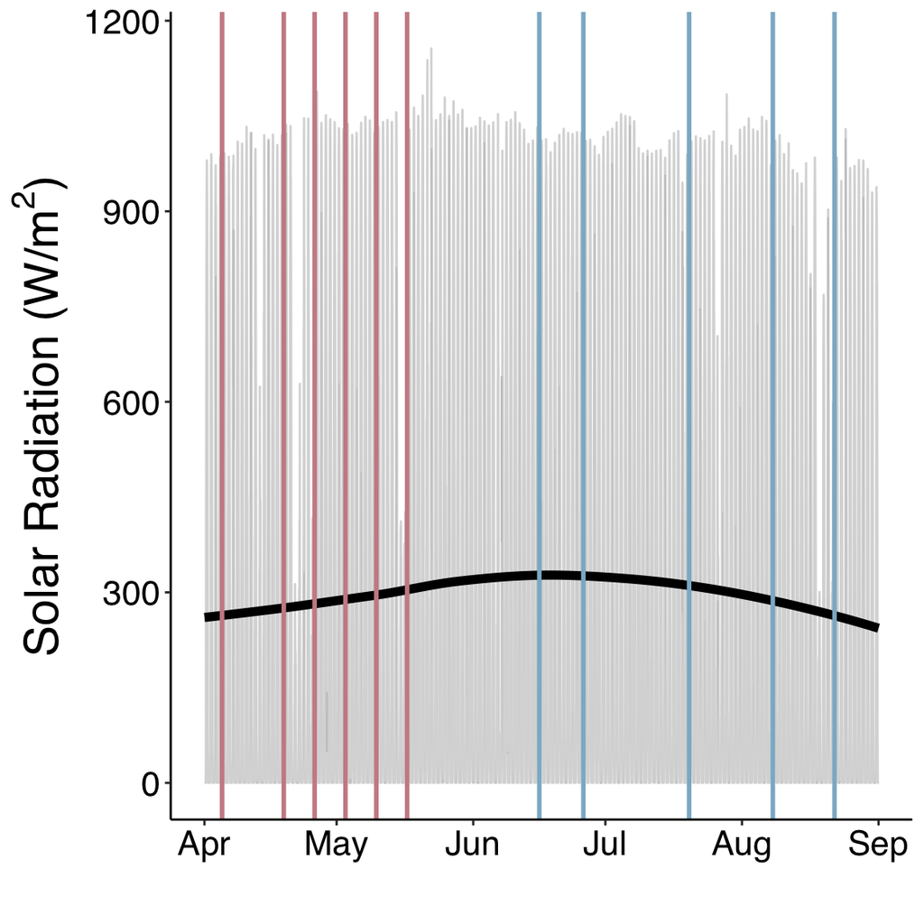

```r
ggplot(data = weather_dat,
       aes(x = date_time,
                y = solar_radiation_W_m2)) +
  # all data
  geom_line(alpha = 0.6,
            color = "gray") +
  # trend over time
  stat_smooth(formula = y ~ x,
              method = "loess",
              color = "black",
              se = F,
              size = 2,
              alpha = 1 ) +
  # sampling dates for BOTH studies
  geom_vline(xintercept = as.POSIXct("2021-04-05 00:00:00"), size = 1,
             color = "lightpink3") +
  geom_vline(xintercept = as.POSIXct("2021-04-19 00:00:00"), size = 1,
             color = "lightpink3") +
  geom_vline(xintercept = as.POSIXct("2021-04-26 00:00:00"), size = 1,
             color = "lightpink3") +
  geom_vline(xintercept = as.POSIXct("2021-05-03 00:00:00"), size = 1,
             color = "lightpink3") +
  geom_vline(xintercept = as.POSIXct("2021-05-10 00:00:00"), size = 1,
             color = "lightpink3") +
  geom_vline(xintercept = as.POSIXct("2021-05-17 00:00:00"), size = 1,
             color = "lightpink3") +
  geom_vline(xintercept = as.POSIXct("2021-06-16 00:00:00"), size = 1,
             color = "lightskyblue3") +
  geom_vline(xintercept = as.POSIXct("2021-06-26 00:00:00"), size = 1,
             color = "lightskyblue3") +
  geom_vline(xintercept = as.POSIXct("2021-07-20 00:00:00"), size = 1,
             color = "lightskyblue3") +
  geom_vline(xintercept = as.POSIXct("2021-08-08 00:00:00"), size = 1,
             color = "lightskyblue3") +
  geom_vline(xintercept = as.POSIXct("2021-08-22 00:00:00"), size = 1,
             color = "lightskyblue3") +
  # rest is formatting
  theme_classic() +
  xlab("") +
  ylab(bquote('Solar Radiation (W/'*m^2*')')) +
  theme(text = element_text(color = "black",
                            family = "sans",
                            size = 22),
        axis.text = element_text(color = "black",
                                 family = "sans",
                                 size = 16),
        legend.text = element_text(color = "black",
                                 family = "sans",
                                 size = 14),
        legend.text.align = 0,
        legend.position = "right"
        ) -> sorad_fig
sorad_fig
```

## Active Season

Create a figure to compare our experimental conditions to daytime conditions throughout the entire active season.

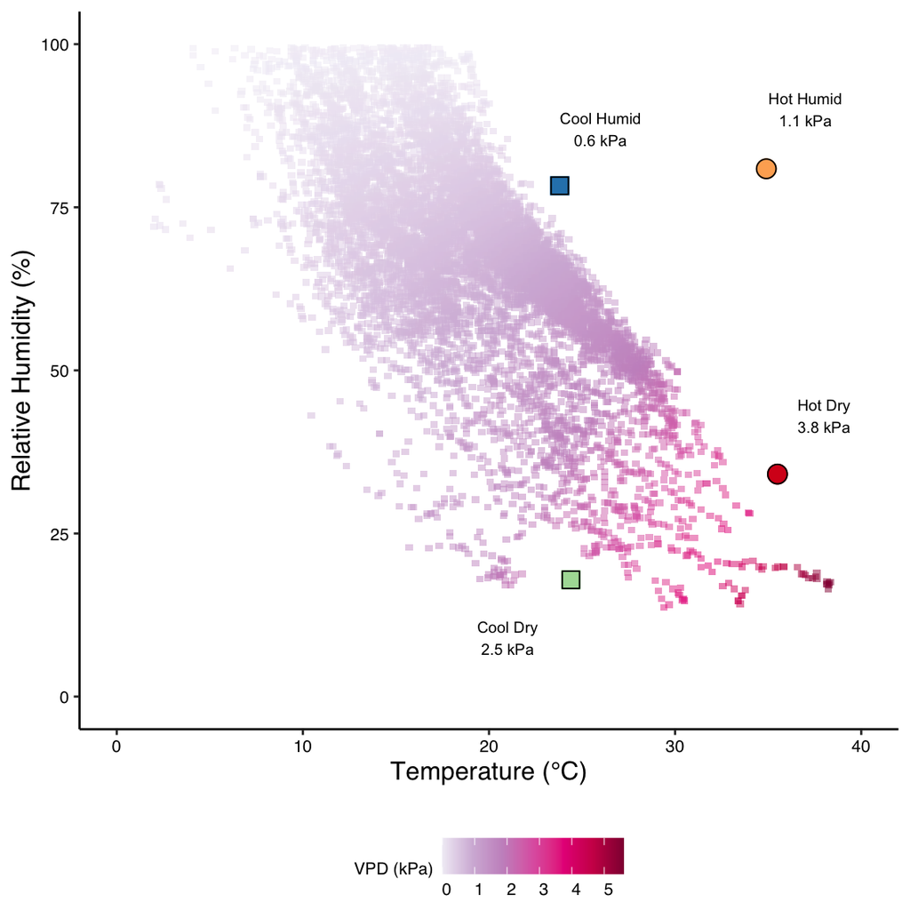

```r
# mean tmt values
tmts <- data.frame(tmt = c("Cool Humid", "Hot Humid", "Cool Dry", "Hot Dry"),
                   VPD_kPa = c(0.6, 1.1, 2.5, 3.8),
                   temp_C = c(23.8, 34.9, 24.4, 35.5),
                   RH_percent = c(78.3, 80.9, 17.9, 34.1))
tmts$tmt <- factor(tmts$tmt,
                   levels = c("Cool Humid", "Hot Humid", "Cool Dry", "Hot Dry"))
# colors, shapes, labels
CH_color <- brewer.pal(4, "Spectral")[c(4)]
HH_color <- brewer.pal(4, "Spectral")[c(2)]
CD_color <- brewer.pal(4, "Spectral")[c(3)]
HD_color <- brewer.pal(4, "Spectral")[c(1)]
my_colors <- c(CH_color, HH_color, CD_color, HD_color)
CH_shp <- 15
HH_shp <- 19
CD_shp <- 15
HD_shp <- 19
my_shapes <- c(CH_shp, HH_shp, CD_shp, HD_shp)
my_labels <- c("Cool Humid\n0.6 kPa",
                               "Hot Humid\n1.1 kPa",
                               "Cool Dry\n2.5 kPa",
                               "Hot Dry\n3.8 kPa")

# plot
ggplot() +
  geom_tile(data = weather_dat_active_szn,
            aes(x = temp_C,
                y = RH_percent,
                fill = VPD_kPa_CN98),
            alpha = 0.5,
            height = 1,
            width = 0.4) +
  geom_point(data = tmts,
             aes(x = temp_C,
                 y = RH_percent),
                 color = my_colors,
                 shape = my_shapes,
              size = 4,
              alpha = 1) +
  geom_point(data = tmts,
             aes(x = temp_C,
                 y = RH_percent),
             shape = c(22,21,22,21), # same as my_shapes, but with no fill
             color = "black",
              size = 4,
              alpha = 1) +
  scale_fill_distiller(palette = "PuRd", direction = 1, name = "VPD (kPa)") +
  theme_classic() +
  #scale_shape_manual(values = my_shapes, name = NULL,
   #                  labels = my_labels) +
  #scale_color_manual(values = my_colors, name = NULL,
   #                  labels = my_labels) +
  xlab("Temperature (°C)") +
  ylab("Relative Humidity (%)") +
  xlim(0,40) + ylim(0,100) +
  #guides(shape = guide_legend(nrow = 4, byrow = TRUE),
   #      #fill = guide_legend(title.position = "left") # makes color ramp weird
    #     ) +
  annotate("text", label = "Cool Humid\n0.6 kPa",
            x = 26, y = 87, size = 2.6, color = "black") +
  annotate("text", label = "Hot Humid\n1.1 kPa",
            x = 37, y = 90, size = 2.6, color = "black") +
  annotate("text", label = "Cool Dry\n2.5 kPa",
            x = 21, y = 9, size = 2.6, color = "black") +
  annotate("text", label = "Hot Dry\n3.8 kPa",
            x = 38, y = 43, size = 2.6, color = "black") +
  theme(text = element_text(color = "black",
                            family = "sans",
                            size = 12),
        axis.text = element_text(color = "black",
                                 family = "sans",
                                 size = 8),
        legend.text = element_text(color = "black",
                                 family = "sans",
                                 size = 8),
        legend.title = element_text(color = "black",
                                 family = "sans",
                                 size = 8),
        legend.text.align = 0,
        legend.position = "bottom",
        legend.title.align = 0.5,
        legend.direction = "horizontal",
        legend.margin = margin(t = 5, unit = "mm")
        #plot.margin = unit(c(0, #top
         #                     0, #right
          #                    0, #bottom
           #                   0), "mm")
        ) -> tmt_weather_fig
tmt_weather_fig
```

```r
# use ggarrange so legend is centered
tmt_weather_fig_formatted <- ggarrange(tmt_weather_fig,
                                        ncol = 1, nrow = 1,
                                        common.legend = TRUE,
                                        legend = "bottom")
```

```r
# save
ggsave(filename = "exp_vs_weather_fig.pdf",
       plot = tmt_weather_fig_formatted,
       path = "./results_figures",
       device = "pdf",
       dpi = 600,
       units = "mm",
       width = 80, height = 100)
```

# Stats

## Variability

```r
variation <- weather_dat %>%
  mutate(study = as.factor(case_when(date_time >= "2021-04-05 00:00:00" &
                                       date_time <= "2021-05-18 00:00:00" ~
                                       "spring",
                                     date_time >= "2021-06-16 00:00:00" &
                                       date_time <= "2021-08-23 00:00:00" ~
                                       "summer"
                                       ))) %>%
  dplyr::filter(complete.cases(study)) %>%
  group_by(study) %>%
  summarise(temp_CV = (sd(temp_C)/mean(temp_C)) *100,
            temp_range = max(temp_C) - min(temp_C),
            VPD_CV = (sd(VPD_kPa_CN98)/mean(VPD_kPa_CN98)) *100,
            VPD_range = max(VPD_kPa_CN98) - min(VPD_kPa_CN98),
            wind_CV = (sd(wind_speed_mph)/mean(wind_speed_mph)) *100,
            wind_range = max(wind_speed_mph) - min(wind_speed_mph),
            sorad_CV = (sd(solar_radiation_W_m2)/mean(solar_radiation_W_m2)) *100,
            sorad_range = max(solar_radiation_W_m2) - min(solar_radiation_W_m2)
            )
variation
```

```
## # A tibble: 2 × 9
##   study  temp_CV temp_range VPD_CV VPD_range wind_CV wind_range sorad_CV sorad…¹
##   <fct>    <dbl>      <dbl>  <dbl>     <dbl>   <dbl>      <dbl>    <dbl>   <dbl>
## 1 spring    34.6       27.2   143.      3.34    98.3       13       133.   1088.
## 2 summer    26.5       28.0   139.      5.60   104.        16.1     125.   1084
## # … with abbreviated variable name ¹sorad_range
```

## SLR ~ Date

Try a simple linear model of weather ~ date:

```r
anova(lm(data = weather_dat_daily, temp_C ~ date))
```

```
## Analysis of Variance Table
##
## Response: temp_C
##            Df Sum Sq Mean Sq F value    Pr(>F)
## date        1 624.63  624.63  128.17 < 2.2e-16 ***
## Residuals 152 740.75    4.87
## ---
## Signif. codes:  0 '***' 0.001 '**' 0.01 '*' 0.05 '.' 0.1 ' ' 1
```

```r
summary(lm(data = weather_dat_daily, VPD_kPa ~ date))
```

```
##
## Call:
## lm(formula = VPD_kPa ~ date, data = weather_dat_daily)
##
## Residuals:
##      Min       1Q   Median       3Q      Max
## -0.45659 -0.16869 -0.09691  0.03457  2.67064
##
## Coefficients:
##               Estimate Std. Error t value Pr(>|t|)
## (Intercept) -6.3660870 11.6908235  -0.545    0.587
## date         0.0003615  0.0006220   0.581    0.562
##
## Residual standard error: 0.3432 on 152 degrees of freedom
## Multiple R-squared:  0.002218,   Adjusted R-squared:  -0.004347
## F-statistic: 0.3378 on 1 and 152 DF,  p-value: 0.5619
```

```r
summary(lm(data = weather_dat_daily, wind_speed_mph ~ date))
```

```
##
## Call:
## lm(formula = wind_speed_mph ~ date, data = weather_dat_daily)
##
## Residuals:
##     Min      1Q  Median      3Q     Max
## -1.7055 -0.4760 -0.2113  0.2062  7.8177
##
## Coefficients:
##              Estimate Std. Error t value Pr(>|t|)
## (Intercept) 96.794848  34.660874   2.793  0.00590 **
## date        -0.005028   0.001844  -2.727  0.00715 **
## ---
## Signif. codes:  0 '***' 0.001 '**' 0.01 '*' 0.05 '.' 0.1 ' ' 1
##
## Residual standard error: 1.017 on 152 degrees of freedom
## Multiple R-squared:  0.04663,    Adjusted R-squared:  0.04036
## F-statistic: 7.434 on 1 and 152 DF,  p-value: 0.007152
```

```r
summary(lm(data = weather_dat_daily, solar_radiation_W_m2 ~ date))
```

```
##
## Call:
## lm(formula = solar_radiation_W_m2 ~ date, data = weather_dat_daily)
##
## Residuals:
##      Min       1Q   Median       3Q      Max
## -290.242   -5.523   18.381   37.258   63.117
##
## Coefficients:
##               Estimate Std. Error t value Pr(>|t|)
## (Intercept) 1384.13275 2182.97056   0.634    0.527
## date          -0.05796    0.11615  -0.499    0.618
##
## Residual standard error: 64.08 on 152 degrees of freedom
## Multiple R-squared:  0.001636,   Adjusted R-squared:  -0.004933
## F-statistic: 0.249 on 1 and 152 DF,  p-value: 0.6185
```

Of the 4 weather variables, mean daily values correlated with date for only temperature (estimate = 0.05, SE = 0.004, df = 152, p < 0.0001) and wind speed (estimate = -0.005, SE = 0.002, df = 152, p = 0.007).

## Daily Humidity

What level of relative humidity do these lizards typically experience?

```r
mean_humid_VPD <- weather_dat %>%
  # filter to be only for study 2
  dplyr::filter(date > "2021-06-15") %>%
  # get daytime values only, 6 am to 8 pm
  dplyr::filter(as.numeric(substr(date_time, 12, 13)) < 20 &
                  as.numeric(substr(date_time, 12, 13)) > 6) %>%
  # get by date first
  group_by(date) %>%
  summarise(VPD_kPa_CN98 = mean(VPD_kPa_CN98),
            RH_percent = mean(RH_percent)) %>%
  # mean across dates
  summarise(mean_VPD = mean(VPD_kPa_CN98),
            sd_VPD = sd(VPD_kPa_CN98),
            mean_RH = mean(RH_percent),
            sd_RH = sd(RH_percent))
mean_humid_VPD
```

```
## # A tibble: 1 × 4
##   mean_VPD sd_VPD mean_RH sd_RH
##      <dbl>  <dbl>   <dbl> <dbl>
## 1    0.801  0.483    73.1  9.28
```

Mean daily relative humidity during the CWL 2021 study was 73±9%, shockingly high!